# Week 5 Homework

Author

Andrew Joyce

Published

October 1, 2023

## 5.2.1 Exercise

Suppose that `p = 2/3`, and `size = 1`.  
Use `dbinom()` to verify the result in Equation 5.1

```r
eq1a <- dbinom(1, size = 1, prob = 2/3)
isTRUE(eq1a == 2/3)
```

```
[1] TRUE
```

```r
eq1b <- dbinom(0, size = 1, prob = 2/3)
isTRUE(eq1b == (1-2/3))
```

```
[1] TRUE
```

```r
eq1c <- dbinom(5, size = 1, prob = 2/3)
isTRUE(eq1c == 0)
```

```
[1] TRUE
```

Use `pbinom()` to verify the results in Equation 5.2

```r
eq2a <- pbinom(-1, size = 1, prob = 2/3)
isTRUE(eq2a == 0)
```

```
[1] TRUE
```

```r
eq2b <- pbinom(0, size = 1, prob = 2/3)
isTRUE(eq2b == (1 - 2/3))
```

```
[1] TRUE
```

```r
eq2c <- pbinom(1, size = 1, prob = 2/3)
isTRUE(eq2c == 1)
```

```
[1] TRUE
```

```r
eq2d <- pbinom(2, size = 1, prob = 2/3)
isTRUE(eq2d == 1)
```

```
[1] TRUE
```

Use `rbinom()` to generate 100 samples from the Bernouilli distribution with `prob = 2/3`. Plot the results in `ggplot` using `geom_bar`.

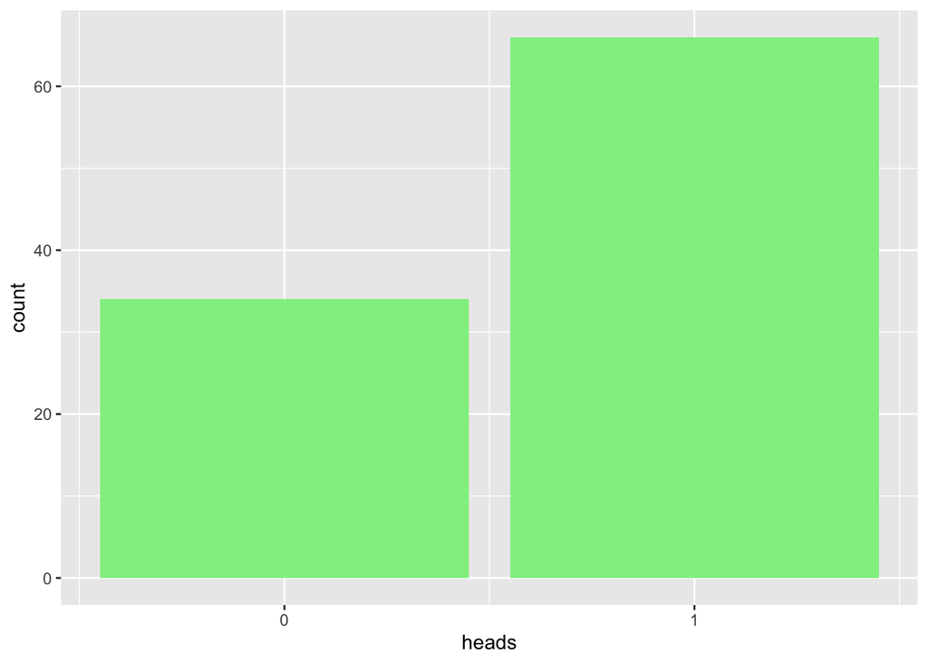

```r
tosses <- tibble(
  heads = (rbinom(100, 1, 2/3))
)

ggplot(tosses, aes(x = heads)) + geom_bar(fill = "lightgreen") +
scale_x_continuous(breaks = 0:1)
```

## 5.3.1 Exercise

The sample space ($\Omega$) of four fair coin flips is as follows:

$$\Omega =
\begin{Bmatrix}
HHHH \\ \\
HHHT \\ HHTH \\ HTHH \\ THHH \\ \\
HHTT \\ TTHH \\ HTTH \\ THHT \\ HTHT \\ THTH \\ \\
HTTT \\ THTT \\ TTHT \\ TTTH \\ \\
TTTT \\
\end{Bmatrix} \to
\begin{Bmatrix}
4 \\ \\
3 \\ 3 \\ 3 \\ 3 \\ \\
2 \\ 2 \\ 2 \\ 2 \\ 2 \\ 2 \\ \\
1 \\ 1 \\ 1 \\ 1 \\ \\
0 \\
\end{Bmatrix}$$

## 5.3.2 Exercise

“How many possible ways are there to get $X = 0$, $X = 1$, $X = 2$, $X = 3$, and $X = 4$?”

- There is 1 way to get $X=0$
- There are 4 ways to get $X = 1$
- There are 6 ways to get $X = 2$
- There are 4 ways to get $X = 3$
- There is 1 way to get $X = 4$.

“What is the probability that $X = 2$?”

- The probability that $X = 2$ is $\frac{6}{16}$ which is equivalent to $\frac{3}{8}$, $0.375$, or $37.5$%.

“Verify this by using the correct R function to calculate the probability that $X = 2$.”

```r
dbinom(2, 4, .5)
```

```
[1] 0.375
```

“Use the correct R function to calculate the probability that $X \leq 1$?”

```r
dbinom(1, 4, .5) + dbinom(0, 4, .5)
```

```
[1] 0.3125
```

## 5.3.3 Exercise

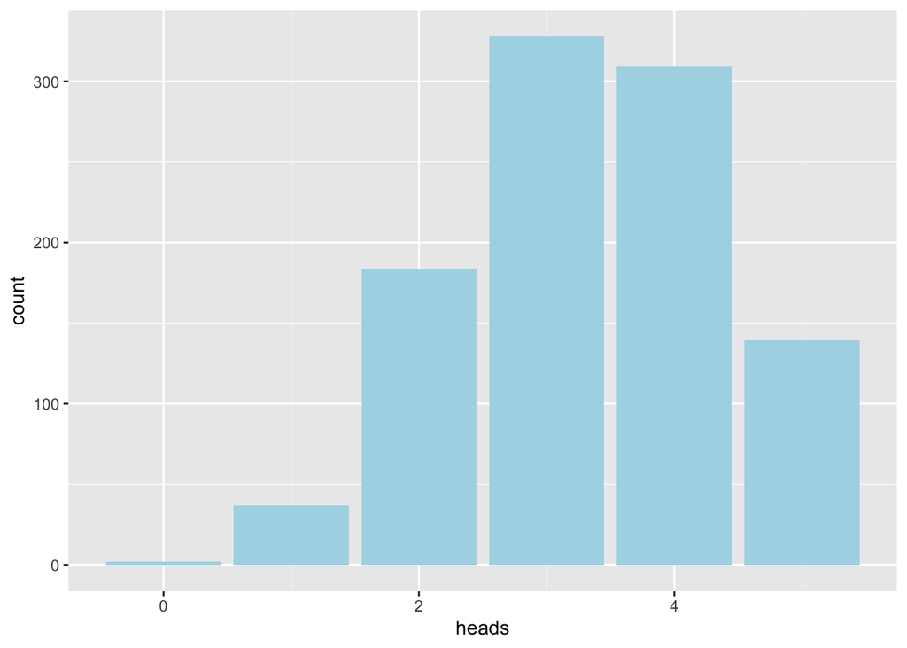

```r
# Use rbinom() to generate 1000 samples from the Binomial distribution with size = 5 and prob = 2/3. Plot the results in ggplot using geom_bar.
tosses2 <- tibble(
  heads = (rbinom(1000, 5, 2/3))
)

ggplot(tosses2, aes(x = heads)) + geom_bar(fill = "lightblue")
```

```r
#Estimate the probability that X is an even number using the mean() function on those 1000 values.

mean(tosses2 == 2 | tosses2 == 4)
```

```
[1] 0.493
```

## 5.3.5 Exercise

“Review 5.3.1 and 5.3.2. What is the probability that $X=2$ when $p = 1/3$ and $n = 4$?”

$$Pr(X=2) = 6 * \frac{1}{3} \cdot \frac{1}{3} \cdot \frac{2}{3} \cdot \frac{2}{3} = \frac{24}{81} = 0.2963 = 29.63\%$$

*There are 6 permutations of getting 2 heads when flipping 4 coins, hence multiplying this probability times 6.

“Verify this by using the correct R function to calculate the probability that $X = 2$.”

```r
dbinom(2, size = 4, prob = 1/3)
```

```
[1] 0.2962963
```

## 5.3.7 Exercise

**Part 1: Verify equation 5.3 using `dbinom`.**

The equation for the binomial coefficient:
$${n \choose x} = \frac{n!}{x! (n - x)!}$$

The probabilities of any binomial distribution are:

$$\Pr(X = x) = {n \choose x} p^x (1-p)^{n-x}$$

I want to verify these, supposing p = 2/3 and size = 15.

```r
outcomes <- c(1:15)

#dbinom loop
results1 <- numeric(length(outcomes))
for(i in seq_along(outcomes)) {
  results1[i] <- dbinom(i, 15, 2/3)
}

#hand calculation loop
results2 <- numeric(length(outcomes))
for(i in seq_along(outcomes)) {
  results2[i] <- choose(15,i)*((2/3)^i)*((1-2/3)^(15-i))
}

#Comparison of values
tibble(results1, results2)
```

```
# A tibble: 15 × 2
     results1   results2
        <dbl>      <dbl>
 1 0.00000209 0.00000209
 2 0.0000293  0.0000293
 3 0.000254   0.000254
 4 0.00152    0.00152
 5 0.00670    0.00670
 6 0.0223     0.0223
 7 0.0574     0.0574
 8 0.115      0.115
 9 0.179      0.179
10 0.214      0.214
11 0.195      0.195
12 0.130      0.130
13 0.0599     0.0599
14 0.0171     0.0171
15 0.00228    0.00228
```

```r
# sum of each of these results should approximate 1.
sum(results1)
```

```
[1] 0.9999999
```

```r
sum(results2)
```

```
[1] 0.9999999
```

**Part 2: Verify equation 5.4 using `pbinom`.**

```r
results3 <- pbinom(q = 0:15, size = 15, prob = 2/3)
results3
```

```
 [1] 6.969172e-08 2.160443e-06 3.143097e-05 2.851088e-04 1.807176e-03
 [6] 8.504271e-03 3.082792e-02 8.823160e-02 2.030389e-01 3.816282e-01
[11] 5.959352e-01 7.907598e-01 9.206429e-01 9.805889e-01 9.977163e-01
[16] 1.000000e+00
```

As q approaches the specified size, the value of the cumulative distribution function approaches 1.

**Warning**

I’m not entirely sure how to “verify” an equation.

## 5.4.1 Exercise

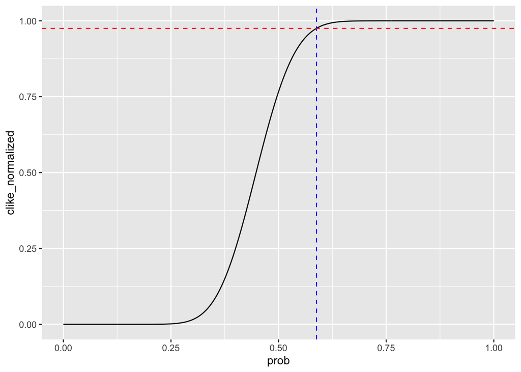

```r
grid <- tibble(prob = seq(0, 1, by = 0.001))
grid$like <- dbinom(21, 47, grid$prob)
grid <- grid |>
  mutate(like = dbinom(21, 47, grid$prob),
         clike_raw = cumsum(like),
         clike_normalized = clike_raw/ sum(like))

ggplot(grid,
       aes(x = prob,
           y = clike_normalized)) + geom_line() +
      geom_vline(xintercept = 0.588, linetype = "dashed", color = "blue") +
      geom_hline(yintercept = 0.975, linetype = "dashed", color = "red" )
```

“What what are the chances that `prob` is equal to or greater than 0.588?”

```r
grid |> filter (prob >= 0.588)
```

```
# A tibble: 413 × 4
    prob   like clike_raw clike_normalized
   <dbl>  <dbl>     <dbl>            <dbl>
 1 0.588 0.0175      20.3            0.975
 2 0.589 0.0170      20.3            0.976
 3 0.59  0.0166      20.4            0.977
 4 0.591 0.0161      20.4            0.978
 5 0.592 0.0157      20.4            0.978
 6 0.593 0.0152      20.4            0.979
 7 0.594 0.0148      20.4            0.980
 8 0.595 0.0144      20.4            0.981
 9 0.596 0.0140      20.4            0.981
10 0.597 0.0136      20.5            0.982
# ℹ 403 more rows
```